# Homework 2: Linear Regression

Supratik Pochampally

## Problem 1: Simple Linear Regression

### 1.

```r
# Load library ISLR
library("ISLR")
# Load Auto data
data(Auto)
# Learn more about the Auto data set
names(Auto)
```

```
## [1] "mpg"          "cylinders"    "displacement" "horsepower"   "weight"
## [6] "acceleration" "year"         "origin"       "name"
```

```r
summary(Auto)
```

```
##       mpg          cylinders      displacement     horsepower        weight
##  Min.   : 9.00   Min.   :3.000   Min.   : 68.0   Min.   : 46.0   Min.   :1613
##  1st Qu.:17.00   1st Qu.:4.000   1st Qu.:105.0   1st Qu.: 75.0   1st Qu.:2225
##  Median :22.75   Median :4.000   Median :151.0   Median : 93.5   Median :2804
##  Mean   :23.45   Mean   :5.472   Mean   :194.4   Mean   :104.5   Mean   :2978
##  3rd Qu.:29.00   3rd Qu.:8.000   3rd Qu.:275.8   3rd Qu.:126.0   3rd Qu.:3615
##  Max.   :46.60   Max.   :8.000   Max.   :455.0   Max.   :230.0   Max.   :5140
##
##   acceleration        year           origin                      name
##  Min.   : 8.00   Min.   :70.00   Min.   :1.000   amc matador       :  5
##  1st Qu.:13.78   1st Qu.:73.00   1st Qu.:1.000   ford pinto        :  5
##  Median :15.50   Median :76.00   Median :1.000   toyota corolla    :  5
##  Mean   :15.54   Mean   :75.98   Mean   :1.577   amc gremlin       :  4
##  3rd Qu.:17.02   3rd Qu.:79.00   3rd Qu.:2.000   amc hornet        :  4
##  Max.   :24.80   Max.   :82.00   Max.   :3.000   chevrolet chevette:  4
##                                                  (Other)           :365
```

```r
# Randomly divide data into train and test sets
set.seed(1234)
i <- sample(1:nrow(Auto), nrow(Auto)*0.75, replace=FALSE)
train <- Auto[i, ]
test <- Auto[-i, ]
```

### 2.

```r
# Simple linear regression on train data
lm1 <- lm(mpg~horsepower, data=train)
lm1
```

```
##
## Call:
## lm(formula = mpg ~ horsepower, data = train)
##
## Coefficients:
## (Intercept)   horsepower
##     39.6486      -0.1567
```

```r
# Summary of the linear model
summary(lm1)
```

```
##
## Call:
## lm(formula = mpg ~ horsepower, data = train)
##
## Residuals:
##      Min       1Q   Median       3Q      Max
## -13.3675  -3.1682  -0.2885   2.8518  17.1357
##
## Coefficients:
##              Estimate Std. Error t value Pr(>|t|)
## (Intercept) 39.648595   0.814676   48.67   <2e-16 ***
## horsepower  -0.156681   0.007276  -21.53   <2e-16 ***
## ---
## Signif. codes:  0 '***' 0.001 '**' 0.01 '*' 0.05 '.' 0.1 ' ' 1
##
## Residual standard error: 4.853 on 292 degrees of freedom
## Multiple R-squared:  0.6136, Adjusted R-squared:  0.6123
## F-statistic: 463.7 on 1 and 292 DF,  p-value: < 2.2e-16
```

```r
# Calculate MSE
mean((summary(lm1)$residuals)^2)
```

```
## [1] 23.39176
```

### 3.

Answer these based on the model summary:

1. mpg = 39.648595 + ((-0.156681) * horsepower)
2. The p-value of the variables is very close to 0 and The F-statistic is much higher than 1, which suggest that there is a strong relationship between horsepower and mpg. However, the R^2 value is relatively low, and we will need more evidence to conclusively state that there is a strong relationship.
3. The correlation between mpg and horsepower is negative.
4. The RSE value shows that our model is only 4.853 mpg off of our data, which is relatively low when considering that the median mpg is 22.75. The R^2 value is 0.6136, which is not particularly strong and means that the variance is not very high. Lastly, the F-statistic is higher than 1 with it’s associated p-value very close to zero, showing that our data is statistically significant.
5. The MSE is 23.39176, meaning that the average squared difference between the data and model is 23.39176 mpg. This is not particularly bad for our model, but can likely be improved upon.

### 4.

The predicted mpg for horsepower of 98 is 24.29381 mpg. This is a reasonable prediction given the plot of the training data for mpg vs. horsepower and the regression line of mpg = 39.6486 + ((-0.1567) * horsepower), as plugging in the value 98 as the horsepower in the equation results in the predicted mpg value of 24.29381.

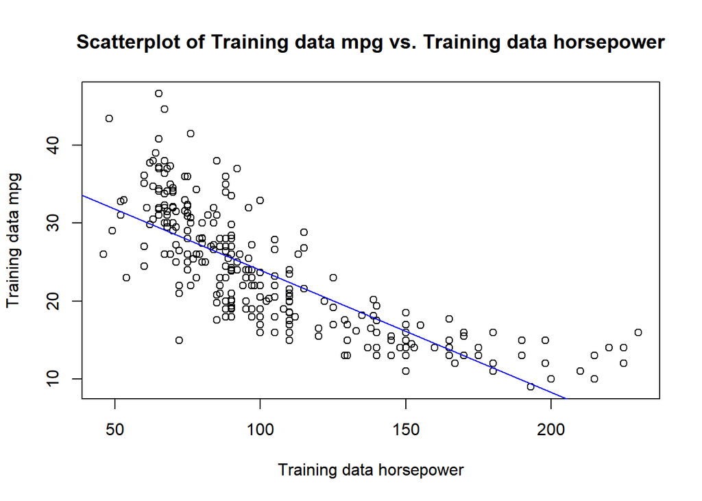

```r
# Plot training data of mpg vs. horsepower
plot(train$horsepower, train$mpg, main="Scatterplot of Training data mpg vs. Training data horsepower", xlab="Training data horsepower", ylab="Training data mpg")
# Draw blue line of linear model
abline(lm1, col="blue")
```

```r
# Predict mpg for horsepower 98
predict(lm1, data.frame(horsepower = 98))
```

```
##        1
## 24.29381
```

### 5.

The correlation between the predicted values and the test data mpg values is 0.7642101. This number represents a strong positive correlation between the predicted values and test data mpg.

The MSE of the test data is 25.71727. This is greater than the MSE for the training data, which was 23.39176. This means that there is a larger average error in the test data than the train data.

```r
# Test on the test data
pred <- predict(lm1, newdata=test)
# Find the correlation between the predicted values and test data
cor <- cor(pred, test$mpg)
cor
```

```
## [1] 0.7642101
```

```r
# Calculate the MSE on the test results
mse <- mean((pred - test$mpg)^2)
mse
```

```
## [1] 25.71727
```

### 6.

The Residuals vs. Fitted plot do not depict a horizontal line, and instead is curved in a bowl-shape, which is evidence of non-linearity from the residuals.

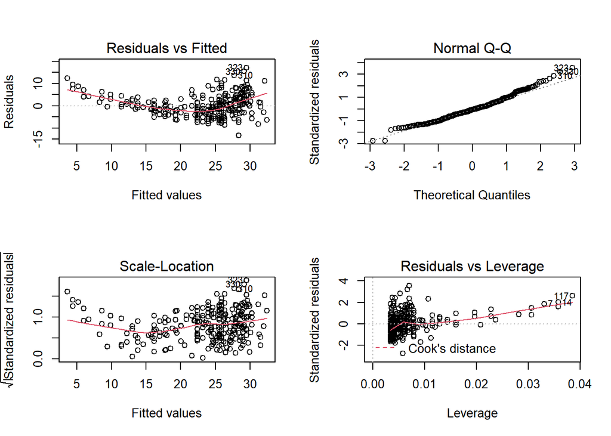

```r
# Create a 2x2 grid for grid for the plots
par(mfrow=c(2, 2 ))
# Plot the residual plots of lm1
plot(lm1)
```

### 7.

The R^2 value of the initial linear model is 0.6135953 and the R^2 value of the second linear model with log(mpg) is 0.6974977 This means that or second linear model with log(mpg) better fits our data.

```r
# Second linear model with log(mpg)
lm2 <- lm(log(mpg)~horsepower, data=train)
# R^2 of initial linear model
summary(lm1)$r.squared
```

```
## [1] 0.6135953
```

```r
# R^2 of second linear model with log(mpg)
summary(lm2)$r.squared
```

```
## [1] 0.6974977
```

### 8.

The second linear model with log(mpg) fits the data better than the initial linear model, likely because the log function damps down the x values closer to the axes and squishes the data closer to the regression line, thus increasing R^2 and resulting in a better model for our data.

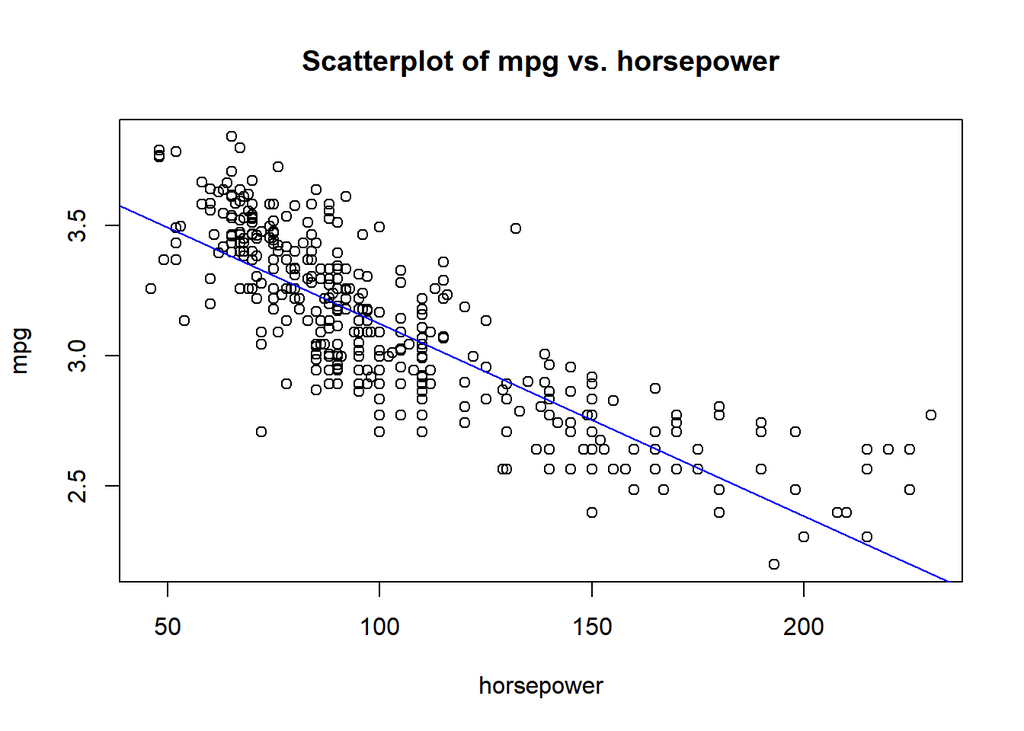

```r
# Plot data of mpg vs. horsepower
plot(Auto$horsepower, log(Auto$mpg), main="Scatterplot of mpg vs. horsepower", xlab="horsepower", ylab="mpg")
# Draw blue line of the second linear model
abline(lm2, col="blue")
```

### 9.

The correlation for the first linear model is 0.7642101 and the correlation for the second linear model is 0.8161675 When comparing the two, we see that the second linear model has a stronger positive correlation than the first linear model.

The MSE of the first linear model is 25.71727 and the MSE for the second linear model is 22.49848 When comparing the two, we see that the second linear model has a smaller average distance between the data and the model.

```r
# Predict on test data using second linear model
pred2 <- exp(predict(lm2, newdata=test))
# Correlation for first linear model
cor
```

```
## [1] 0.7642101
```

```r
# Correlation for second linear model
cor2 <- cor(pred2, test$mpg)
cor2
```

```
## [1] 0.8161675
```

```r
# MSE for first linear model
mse
```

```
## [1] 25.71727
```

```r
# MSE for second linear model
mse2 <- mean((pred2 - test$mpg)^2)
mse2
```

```
## [1] 22.49848
```

### 10.

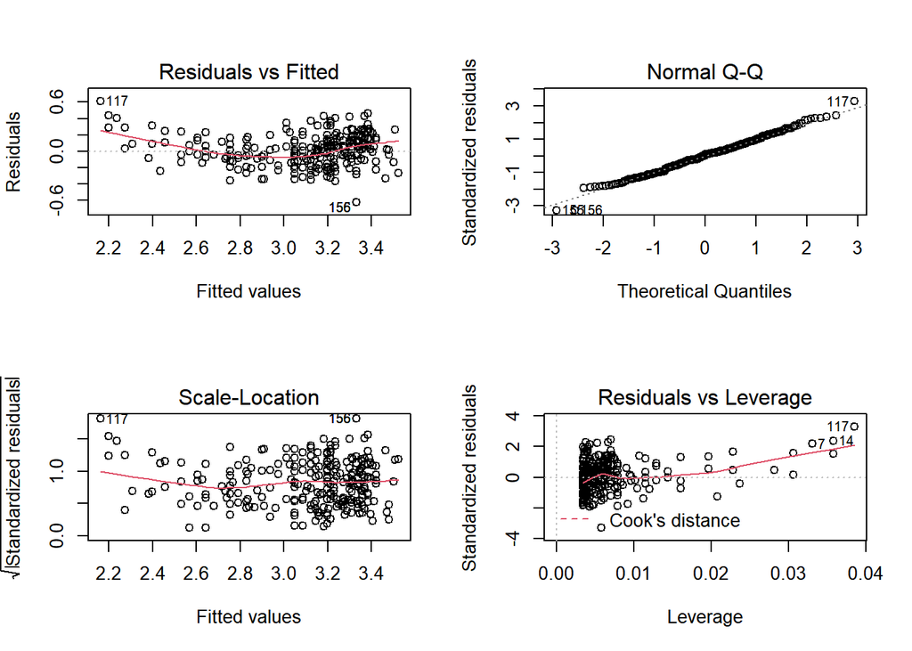

```r
# Create a 2x2 grid for grid for the plots
par(mfrow=c(2, 2 ))
# Plot the residual plots of lm2
plot(lm2)
```

## Problem 2: Multiple Linear Regression

### 1.

Positive correlations:

- weight vs. displacement
- horsepower vs. weight
- displacement vs. horsepower

Negative correlations:

- mpg vs. weight
- displacement vs. mpg
- horsepower vs. mpg

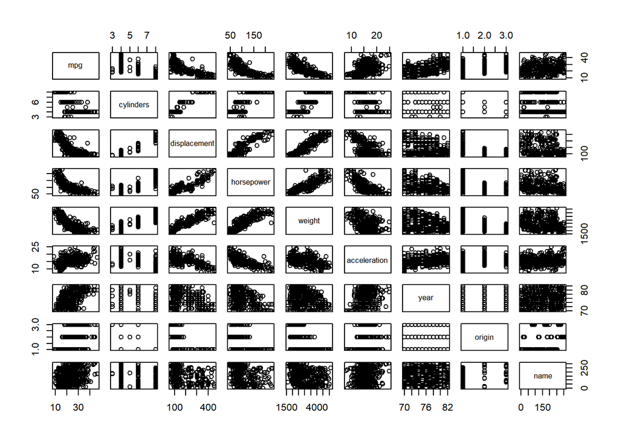

```r
# Display scatterplot matrix of all the variables in the data set
pairs(Auto)
```

### 2.

2 strongest positive correlations:

- displacement vs. cylinders = 0.9508233
- displacement vs. weight = 0.9329944

2 strongest negative correlations:

- weight vs. mpg = -0.8322442
- displacement vs. mpg = -0.8051269

```r
# Display the matrix of correlations between all variables excluding name
cor(Auto[1:8])
```

```
##                     mpg  cylinders displacement horsepower     weight
## mpg           1.0000000 -0.7776175   -0.8051269 -0.7784268 -0.8322442
## cylinders    -0.7776175  1.0000000    0.9508233  0.8429834  0.8975273
## displacement -0.8051269  0.9508233    1.0000000  0.8972570  0.9329944
## horsepower   -0.7784268  0.8429834    0.8972570  1.0000000  0.8645377
## weight       -0.8322442  0.8975273    0.9329944  0.8645377  1.0000000
## acceleration  0.4233285 -0.5046834   -0.5438005 -0.6891955 -0.4168392
## year          0.5805410 -0.3456474   -0.3698552 -0.4163615 -0.3091199
## origin        0.5652088 -0.5689316   -0.6145351 -0.4551715 -0.5850054
##              acceleration       year     origin
## mpg             0.4233285  0.5805410  0.5652088
## cylinders      -0.5046834 -0.3456474 -0.5689316
## displacement   -0.5438005 -0.3698552 -0.6145351
## horsepower     -0.6891955 -0.4163615 -0.4551715
## weight         -0.4168392 -0.3091199 -0.5850054
## acceleration    1.0000000  0.2903161  0.2127458
## year            0.2903161  1.0000000  0.1815277
## origin          0.2127458  0.1815277  1.0000000
```

### 3.

```r
# Make the origin variable a factor
Auto$origin <- factor(Auto$origin)
# Multiple linear regression of all variables excluding name
lm3 <- lm(mpg~.-name, data = Auto)
# Summary of model
summary(lm3)
```

```
##
## Call:
## lm(formula = mpg ~ . - name, data = Auto)
##
## Residuals:
##     Min      1Q  Median      3Q     Max
## -9.0095 -2.0785 -0.0982  1.9856 13.3608
##
## Coefficients:
##                Estimate Std. Error t value Pr(>|t|)
## (Intercept)  -1.795e+01  4.677e+00  -3.839 0.000145 ***
## cylinders    -4.897e-01  3.212e-01  -1.524 0.128215
## displacement  2.398e-02  7.653e-03   3.133 0.001863 **
## horsepower   -1.818e-02  1.371e-02  -1.326 0.185488
## weight       -6.710e-03  6.551e-04 -10.243  < 2e-16 ***
## acceleration  7.910e-02  9.822e-02   0.805 0.421101
## year          7.770e-01  5.178e-02  15.005  < 2e-16 ***
## origin2       2.630e+00  5.664e-01   4.643 4.72e-06 ***
## origin3       2.853e+00  5.527e-01   5.162 3.93e-07 ***
## ---
## Signif. codes:  0 '***' 0.001 '**' 0.01 '*' 0.05 '.' 0.1 ' ' 1
##
## Residual standard error: 3.307 on 383 degrees of freedom
## Multiple R-squared:  0.8242, Adjusted R-squared:  0.8205
## F-statistic: 224.5 on 8 and 383 DF,  p-value: < 2.2e-16
```

### 4.

The Residuals vs. Fitted plot do not depict a horizontal line, and instead is curved in a bowl-shape, which is evidence of some problems with the fit.

Observation 14 seems to be a leverage point, as it has an unusual x-value as seen in the Residuals vs. Leverage plot.

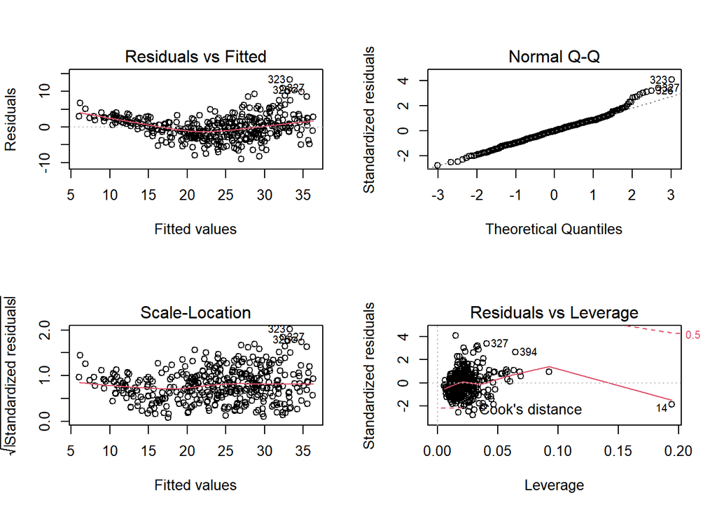

```r
# Create a 2x2 grid for grid for the plots
par(mfrow=c(2, 2 ))
# Plot the residual plots of lm3
plot(lm3)
```

```r
# Print observation 14
Auto[14, ]
```

|  | mpg | cylinders | displacement | horsepower | weight | acceleration | year | origin | name |
| --- | --- | --- | --- | --- | --- | --- | --- | --- | --- |
| 14 | 14 | 8 | 455 | 225 | 3086 | 10 | 70 | 1 | buick estate wagon (sw) |

### 5.

The R^2 value of the initial multiple regression model using all variables (except name) as predictors was 0.8242. The R^2 value of the second multiple regression model using all variables (except name) as predictors as well as weight and cylinders as interaction effects is 0.8556. This increase in the R^2 value shows that the second model outperformed the first one.

```r
# Multiple regression model of every variable and the interaction effect between weight and cylinders
lm4 <- lm(mpg~.-name+weight*cylinders, data = Auto)
# Summary of model
summary(lm4)
```

```
##
## Call:
## lm(formula = mpg ~ . - name + weight * cylinders, data = Auto)
##
## Residuals:
##      Min       1Q   Median       3Q      Max
## -10.3915  -1.6064   0.0071   1.5159  12.7015
##
## Coefficients:
##                    Estimate Std. Error t value Pr(>|t|)
## (Intercept)       5.9654240  4.9902749   1.195 0.232668
## cylinders        -5.0123499  0.5755384  -8.709  < 2e-16 ***
## displacement      0.0195375  0.0069624   2.806 0.005270 **
## horsepower       -0.0325307  0.0125397  -2.594 0.009846 **
## weight           -0.0152216  0.0011071 -13.749  < 2e-16 ***
## acceleration      0.0991623  0.0891602   1.112 0.266760
## year              0.8061374  0.0471024  17.115  < 2e-16 ***
## origin2           1.9482641  0.5194344   3.751 0.000204 ***
## origin3           1.6121198  0.5197641   3.102 0.002068 **
## cylinders:weight  0.0014996  0.0001645   9.114  < 2e-16 ***
## ---
## Signif. codes:  0 '***' 0.001 '**' 0.01 '*' 0.05 '.' 0.1 ' ' 1
##
## Residual standard error: 3.001 on 382 degrees of freedom
## Multiple R-squared:  0.8556, Adjusted R-squared:  0.8522
## F-statistic: 251.5 on 9 and 382 DF,  p-value: < 2.2e-16
```

```r
# Call anova() function to compare the initial and second linear models
anova(lm3, lm4)
```

|  | Res.Df | RSS | Df | Sum of Sq | F | Pr(>F) |
| --- | --- | --- | --- | --- | --- | --- |
| 1 | 383 | 4187.392 | NA | NA | NA | NA |
| 2 | 382 | 3439.530 | 1 | 747.8616 | 83.05876 | 4.568109e-18 |